# Survival Analysis

Colorectal Cancer | Necroptosis | Unique Genes per RCD Type | Log Fold Change

Mark Edward M. Gonzales[^1]

Dr. Anish M.S. Shrestha[^2]

## I. Preliminaries

### Loading libraries

```r
library("tidyverse")
library("tibble")
library("msigdbr")
library("ggplot2")
library("TCGAbiolinks")
library("RNAseqQC")
library("DESeq2")
library("ensembldb")
library("purrr")
library("magrittr")
library("vsn")
library("matrixStats")
library("dplyr")
library("grex")
library("survminer")
library("survival")
```

## II. Downloading the TCGA gene expression data

Create a function for downloading TCGA gene expression data.

For more detailed documentation, refer to `2. Differential Gene Expression Analysis - TCGA.Rmd`.

```r
query_and_filter_samples <- function(project) {
  query_tumor <- GDCquery(
    project = project,
    data.category = "Transcriptome Profiling",
    data.type = "Gene Expression Quantification",
    experimental.strategy = "RNA-Seq",
    workflow.type = "STAR - Counts",
    access = "open",
    sample.type = "Primary Tumor"
  )
  tumor <- getResults(query_tumor)

  query_normal <- GDCquery(
    project = project,
    data.category = "Transcriptome Profiling",
    data.type = "Gene Expression Quantification",
    experimental.strategy = "RNA-Seq",
    workflow.type = "STAR - Counts",
    access = "open",
    sample.type = "Solid Tissue Normal"
  )
  normal <- getResults(query_normal)

  submitter_ids <- inner_join(tumor, normal, by = "cases.submitter_id") %>%
    dplyr::select(cases.submitter_id)
  tumor <- tumor %>%
    dplyr::filter(cases.submitter_id %in% submitter_ids$cases.submitter_id)
  normal <- normal %>%
    dplyr::filter(cases.submitter_id %in% submitter_ids$cases.submitter_id)

  samples <- rbind(tumor, normal)
  unique(samples$sample_type)

  query_project <- GDCquery(
    project = project,
    data.category = "Transcriptome Profiling",
    data.type = "Gene Expression Quantification",
    experimental.strategy = "RNA-Seq",
    workflow.type = "STAR - Counts",
    access = "open",
    sample.type = c("Solid Tissue Normal", "Primary Tumor"),
    barcode = as.list(samples$sample.submitter_id)
  )

  # If this is your first time running this notebook (i.e., you have not yet downloaded the results of the query in the previous block),
  # uncomment the line below

  # GDCdownload(query_project)

  return(list(samples = samples, query_project = query_project))
}
```

Download the TCGA gene expression data for colorectal cancer (TCGA-COAD).

```r
projects <- c("TCGA-COAD")

with_results_projects <- c()

samples <- list()
project_data <- list()

for (project in projects) {
  result <- tryCatch(
    {
      result <- query_and_filter_samples(project)
      samples[[project]] <- result$samples
      project_data[[project]] <- result$query_project

      with_results_projects <- c(with_results_projects, project)
    },
    error = function(e) {

    }
  )
}
```

Running the code block above should generate and populate a directory named `GDCdata`.

## III. Data preprocessing

Construct the RNA-seq count matrix for each cancer type.

```r
tcga_data <- list()
tcga_matrix <- list()

projects <- with_results_projects
for (project in projects) {
  tcga_data[[project]] <- GDCprepare(project_data[[project]], summarizedExperiment = TRUE)
}
```

```r
for (project in projects) {
  count_matrix <- assay(tcga_data[[project]], "unstranded")

  # Remove duplicate entries
  count_matrix_df <- data.frame(count_matrix)
  count_matrix_df <- count_matrix_df[!duplicated(count_matrix_df), ]
  count_matrix <- data.matrix(count_matrix_df)
  rownames(count_matrix) <- cleanid(rownames(count_matrix))
  count_matrix <- count_matrix[!(duplicated(rownames(count_matrix)) | duplicated(rownames(count_matrix), fromLast = TRUE)), ]

  tcga_matrix[[project]] <- count_matrix
}
```

Format the `samples` table so that it can be fed as input to DESeq2.

```r
for (project in projects) {
  rownames(samples[[project]]) <- samples[[project]]$cases
  samples[[project]] <- samples[[project]] %>%
    dplyr::select(case = "cases.submitter_id", type = "sample_type")
  samples[[project]]$type <- str_replace(samples[[project]]$type, "Solid Tissue Normal", "normal")
  samples[[project]]$type <- str_replace(samples[[project]]$type, "Primary Tumor", "tumor")
}
```

DESeq2 requires the row names of `samples` should be identical to the column names of `count_matrix`.

```r
for (project in projects) {
  colnames(tcga_matrix[[project]]) <- gsub(x = colnames(tcga_matrix[[project]]), pattern = "\\.", replacement = "-")
  tcga_matrix[[project]] <- tcga_matrix[[project]][, rownames(samples[[project]])]

  # Sanity check
  print(all(colnames(tcga_matrix[[project]]) == rownames(samples[[project]])))
}
```

## IV. Differential gene expression analysis

For more detailed documentation on obtaining the gene set, refer to `7. Differential Gene Expression Analysis - TCGA - Pan-cancer - Unique Genes.Rmd`.

```r
RCDdb <- "temp/unique_genes/necroptosis_ferroptosis_pyroptosis/"
```

Write utility functions for filtering the gene sets, performing differential gene expression analysis, plotting the results, and performing variance-stabilizing transformation.

```r
filter_gene_set_and_perform_dgea <- function(genes) {
  tcga_rcd <- list()

  for (project in projects) {
    rownames(genes) <- genes$gene_id
    tcga_rcd[[project]] <- tcga_matrix[[project]][rownames(tcga_matrix[[project]]) %in% genes$gene_id, ]
    tcga_rcd[[project]] <- tcga_rcd[[project]][, rownames(samples[[project]])]
  }

  dds_rcd <- list()
  res_rcd <- list()

  for (project in projects) {
    print(project)
    print("=============")
    dds <- DESeqDataSetFromMatrix(
      countData = tcga_rcd[[project]],
      colData = samples[[project]],
      design = ~type
    )
    dds <- filter_genes(dds, min_count = 10)
    dds$type <- relevel(dds$type, ref = "normal")
    dds_rcd[[project]] <- DESeq(dds)
    res_rcd[[project]] <- results(dds_rcd[[project]])
  }

  deseq.bbl.data <- list()

  for (project in projects) {
    deseq.results <- res_rcd[[project]]
    deseq.bbl.data[[project]] <- data.frame(
      row.names = rownames(deseq.results),
      baseMean = deseq.results$baseMean,
      log2FoldChange = deseq.results$log2FoldChange,
      lfcSE = deseq.results$lfcSE,
      stat = deseq.results$stat,
      pvalue = deseq.results$pvalue,
      padj = deseq.results$padj,
      cancer_type = project,
      gene_symbol = genes[rownames(deseq.results), "gene"]
    )
  }

  deseq.bbl.data.combined <- bind_rows(deseq.bbl.data)
  deseq.bbl.data.combined <- dplyr::filter(deseq.bbl.data.combined, abs(log2FoldChange) >= 1.5 & padj < 0.05)

  return(deseq.bbl.data.combined)
}
```

```r
plot_dgea <- function(deseq.bbl.data.combined) {
  sizes <- c("<10^-15" = 4, "10^-10" = 3, "10^-5" = 2, "0.05" = 1)

  deseq.bbl.data.combined <- deseq.bbl.data.combined %>%
    mutate(fdr_category = cut(padj,
      breaks = c(-Inf, 1e-15, 1e-10, 1e-5, 0.05),
      labels = c("<10^-15", "10^-10", "10^-5", "0.05"),
      right = FALSE
    ))

  top_genes <- deseq.bbl.data.combined %>%
    group_by(cancer_type) %>%
    mutate(rank = rank(-abs(log2FoldChange))) %>%
    dplyr::filter(rank <= 10) %>%
    ungroup()

  ggplot(top_genes, aes(y = cancer_type, x = gene_symbol, size = fdr_category, fill = log2FoldChange)) +
    geom_point(alpha = 0.5, shape = 21, color = "black") +
    scale_size_manual(values = sizes) +
    scale_fill_gradient2(low = "blue", mid = "white", high = "red", limits = c(min(deseq.bbl.data.combined$log2FoldChange), max(deseq.bbl.data.combined$log2FoldChange))) +
    theme_minimal() +
    theme(
      axis.text.x = element_text(size = 9, angle = 90, hjust = 1)
    ) +
    theme(legend.position = "bottom") +
    theme(legend.position = "bottom") +
    labs(size = "Adjusted p-value", fill = "log2 FC", y = "Cancer type", x = "Gene")
}
```

```r
perform_vsd <- function(genes) {
  tcga_rcd <- list()

  for (project in projects) {
    rownames(genes) <- genes$gene_id
    tcga_rcd[[project]] <- tcga_matrix[[project]][rownames(tcga_matrix[[project]]) %in% genes$gene_id, ]
    tcga_rcd[[project]] <- tcga_rcd[[project]][, rownames(samples[[project]])]
  }

  vsd_rcd <- list()

  for (project in projects) {
    print(project)
    print("=============")
    dds <- DESeqDataSetFromMatrix(
      countData = tcga_rcd[[project]],
      colData = samples[[project]],
      design = ~type
    )
    dds <- filter_genes(dds, min_count = 10)

    # Perform variance stabilization
    dds <- estimateSizeFactors(dds)
    nsub <- sum(rowMeans(counts(dds, normalized = TRUE)) > 10)
    vsd <- vst(dds, nsub = nsub)
    vsd_rcd[[project]] <- assay(vsd)
  }

  return(vsd_rcd)
}
```

#### Necroptosis

Fetch the gene set of interest.

```r
genes <- read.csv(paste0(RCDdb, "Necroptosis.csv"))
print(genes)
```

| deathtype | gene | description | gene_id | gene_biotype | pmid | comment |
| --- | --- | --- | --- | --- | --- | --- |
| Necroptosis | RBCK1 | RANBP2-type and C3HC4-type zinc finger containing 1 | ENSG00000125826.22 | protein_coding | 36248876 | RBCK1 is highly expressed in ccRCC and regulates the immune suppressive microenvironment of tumors. In addition, RBCK1 can also promote chemoresistance and stemness in colorectal cancer. |
| Necroptosis | JAK2 | Janus kinase 2 | ENSG00000096968.14 | protein_coding | 31729527 | The release of CCL2 is necroptosis-dependent. CCL2 released by TAA can activate the Notch signaling pathway through the JAK2/STAT3 pathway, which directly maintains the stemness of MBSCs. |
| Necroptosis | ZBP1 | Z-DNA binding protein 1 | ENSG00000124256.15 | protein_coding | 36917643 | _BP1 is a protein that mediates Necroptosis, interacts with kinase RIPK3, and participates in forming necrosomes. |
| Necroptosis | RNF31 | ring finger protein 31 | ENSG00000092098.18 | protein_coding | 29728512 | RNF31, also known as HOIP, is associated with necroptosis. It is a key enzyme in the ribonuclease polymerase-induced cell death pathway. |
| Necroptosis | IFNB1 | interferon beta 1 | ENSG00000171855.7 | protein_coding | 23601685 | The relationship between IFNB1 and Necroptosis is that Poly IC stimulation of dendritic cells (DCs) induces Necroptosis through the signaling pathway mediated by IPS-1 and RIP-1, while also promoting … |
| Necroptosis | TRAF5 | TNF receptor associated factor 5 | ENSG00000082512.15 | protein_coding | 33555197 | METTL3 enabled OX resistance in CRC cells by inhibiting TRAF5-mediated Necroptosis. |
| Necroptosis | BIRC2 | baculoviral IAP repeat containing 2 | ENSG00000110330.10 | protein_coding | 27469115 | Approximately 30% of HNSCC patients exhibit FADD/BIRC2 genomic amplification, which is correlated with HPV-negative HNSCC and worse prognosis. |
| Necroptosis | TRAF2 | TNF receptor associated factor 2 | ENSG00000127191.18 | protein_coding | 25882049 | TRAF2 inhibits Necroptosis by modulating the signaling complex containing receptor-interacting protein kinases RIPK1 and RIPK3 (the necrosome) and mixed lineage kinase-domain-like (MLKL), which drive … |
| Necroptosis | BCL2 | BCL2 apoptosis regulator | ENSG00000171791.14 | protein_coding | 31634424 | Fisetin can reduce the expression of the anti-apoptotic protein BCL2 and increase the levels of pro-apoptotic proteins Bax, caspase-3, and PARP in HepG2 cells, inducing cell death through apoptosis pa… |
| Necroptosis | STAT4 | signal transducer and activator of transcription 4 | ENSG00000138378.19 | protein_coding | 36518671 | The STAT4 gene is mentioned to be related to Necroptosis. STAT4 deficiency has a protective effect against neointima formation following arterial injury in mice and is also involved in the development… |

[output cut: 44 more lines]

```r
genes$gene_id <- cleanid(genes$gene_id)
genes <- distinct(genes, gene_id, .keep_all = TRUE)
genes <- subset(genes, gene_id != "")
genes
```

|  | deathtype | gene | description | gene_id | gene_biotype | pmid | comment |
| --- | --- | --- | --- | --- | --- | --- | --- |
| 1 | Necroptosis | RBCK1 | RANBP2-type and C3HC4-type zinc finger containing 1 | ENSG00000125826 | protein_coding | 36248876 | RBCK1 is highly expressed in ccRCC and regulates the immune suppressive microenvironment of tumors. In addition, RBCK1 can also promote chemoresistance and stemness in colorectal cancer. |
| 2 | Necroptosis | JAK2 | Janus kinase 2 | ENSG00000096968 | protein_coding | 31729527 | The release of CCL2 is necroptosis-dependent. CCL2 released by TAA can activate the Notch signaling pathway through the JAK2/STAT3 pathway, which directly maintains the stemness of MBSCs. |
| 3 | Necroptosis | ZBP1 | Z-DNA binding protein 1 | ENSG00000124256 | protein_coding | 36917643 | _BP1 is a protein that mediates Necroptosis, interacts with kinase RIPK3, and participates in forming necrosomes. |
| 4 | Necroptosis | RNF31 | ring finger protein 31 | ENSG00000092098 | protein_coding | 29728512 | RNF31, also known as HOIP, is associated with necroptosis. It is a key enzyme in the ribonuclease polymerase-induced cell death pathway. |
| 5 | Necroptosis | IFNB1 | interferon beta 1 | ENSG00000171855 | protein_coding | 23601685 | The relationship between IFNB1 and Necroptosis is that Poly IC stimulation of dendritic cells (DCs) induces Necroptosis through the signaling pathway mediated by IPS-1 and RIP-1, while also promoting … |
| 6 | Necroptosis | TRAF5 | TNF receptor associated factor 5 | ENSG00000082512 | protein_coding | 33555197 | METTL3 enabled OX resistance in CRC cells by inhibiting TRAF5-mediated Necroptosis. |
| 7 | Necroptosis | BIRC2 | baculoviral IAP repeat containing 2 | ENSG00000110330 | protein_coding | 27469115 | Approximately 30% of HNSCC patients exhibit FADD/BIRC2 genomic amplification, which is correlated with HPV-negative HNSCC and worse prognosis. |
| 8 | Necroptosis | TRAF2 | TNF receptor associated factor 2 | ENSG00000127191 | protein_coding | 25882049 | TRAF2 inhibits Necroptosis by modulating the signaling complex containing receptor-interacting protein kinases RIPK1 and RIPK3 (the necrosome) and mixed lineage kinase-domain-like (MLKL), which drive … |
| 9 | Necroptosis | BCL2 | BCL2 apoptosis regulator | ENSG00000171791 | protein_coding | 31634424 | Fisetin can reduce the expression of the anti-apoptotic protein BCL2 and increase the levels of pro-apoptotic proteins Bax, caspase-3, and PARP in HepG2 cells, inducing cell death through apoptosis pa… |
| 10 | Necroptosis | STAT4 | signal transducer and activator of transcription 4 | ENSG00000138378 | protein_coding | 36518671 | The STAT4 gene is mentioned to be related to Necroptosis. STAT4 deficiency has a protective effect against neointima formation following arterial injury in mice and is also involved in the development… |

[output cut: 44 more lines]

Filter the genes to include only those in the gene set of interest, and then perform differential gene expression analysis.

```r
deseq.bbl.data.combined <- filter_gene_set_and_perform_dgea(genes)
```

```
[1] "TCGA-COAD"
[1] "============="
```

```r
deseq.bbl.data.combined
```

|  | baseMean | log2FoldChange | lfcSE | stat | pvalue | padj | cancer_type | gene_symbol |
| --- | --- | --- | --- | --- | --- | --- | --- | --- |
| ENSG00000070808 | 30.88638 | -1.516869 | 0.2658892 | -5.70489 | 1.164180e-08 | 3.085076e-08 | TCGA-COAD | CAMK2A |
| ENSG00000082512 | 1700.52036 | 1.652707 | 0.1524952 | 10.83777 | 2.279633e-27 | 2.416411e-26 | TCGA-COAD | TRAF5 |
| ENSG00000121858 | 4556.88590 | -1.502531 | 0.1283906 | -11.70281 | 1.233014e-31 | 3.267488e-30 | TCGA-COAD | TNFSF10 |
| ENSG00000164342 | 903.01181 | -1.828384 | 0.1582323 | -11.55506 | 6.959979e-31 | 1.229596e-29 | TCGA-COAD | TLR3 |

Plot the results.

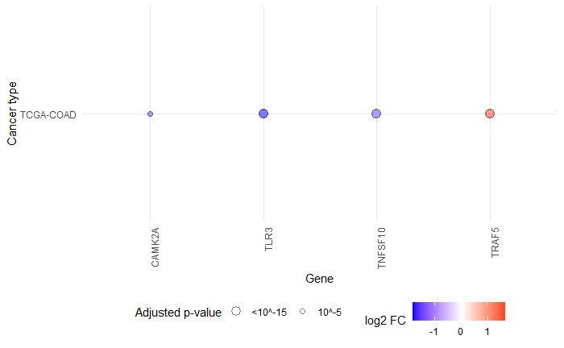

```r
plot_dgea(deseq.bbl.data.combined)
```

Perform variance-stabilizing transformation for further downstream analysis (i.e., for survival analysis).

```r
vsd <- perform_vsd(genes)
```

```
[1] "TCGA-COAD"
[1] "============="
```

## V. Downloading the clinical data

Download clinical data from TCGA, and perform some preprocessing: - The `deceased` column should be `FALSE` if the patient is alive and `TRUE` otherwise - The `overall_survival` column should reflect the follow-up time if the patient is alive and the days to death otherwise

```r
download_clinical_data <- function(project) {
  clinical_data <- GDCquery_clinic(project)
  clinical_data$deceased <- ifelse(clinical_data$vital_status == "Alive", FALSE, TRUE)
  clinical_data$overall_survival <- ifelse(clinical_data$vital_status == "Alive",
    clinical_data$days_to_last_follow_up,
    clinical_data$days_to_death
  )

  return(clinical_data)
}
```

```r
tcga_clinical <- list()
for (project in projects) {
  tcga_clinical[[project]] <- download_clinical_data(project)
}
```

## VI. Performing survival analysis

Write utility functions for performing survival analysis.

```r
construct_gene_df <- function(gene_of_interest, project) {
  normal_df <- tcga_matrix[[project]] %>%
    as.data.frame() %>%
    rownames_to_column(var = "gene_id") %>%
    gather(key = "case_id", value = "counts", -gene_id) %>%
    left_join(., genes, by = "gene_id") %>%
    dplyr::filter(gene == gene_of_interest) %>%
    dplyr::filter(case_id %in% rownames(samples[[project]] %>% dplyr::filter(type == "normal")))
  normal_df$case_id <- paste0(sapply(strsplit(as.character(normal_df$case_id), "-"), `[`, 1), '-',
                            sapply(strsplit(as.character(normal_df$case_id), "-"), `[`, 2), '-',
                            sapply(strsplit(as.character(normal_df$case_id), "-"), `[`, 3))

  tumor_df <- tcga_matrix[[project]] %>%
      as.data.frame() %>%
      rownames_to_column(var = "gene_id") %>%
      gather(key = "case_id", value = "counts", -gene_id) %>%
      left_join(., genes, by = "gene_id") %>%
      dplyr::filter(gene == gene_of_interest) %>%
      dplyr::filter(case_id %in% rownames(samples[[project]] %>% dplyr::filter(type == "tumor")))
  tumor_df$case_id <- paste0(sapply(strsplit(as.character(tumor_df$case_id), "-"), `[`, 1), '-',
                            sapply(strsplit(as.character(tumor_df$case_id), "-"), `[`, 2), '-',
                            sapply(strsplit(as.character(tumor_df$case_id), "-"), `[`, 3))

  gene_df <- inner_join(normal_df, tumor_df, by = c("gene_id", "case_id", "deathtype", "gene", "description", "gene_biotype", "pmid", "comment"))
  gene_df$log_fold = log2(gene_df$counts.y / gene_df$counts.x)

  gene_df$strata <- ifelse(abs(gene_df$log_fold) >= 1.5, "HIGH", "LOW")
  gene_df <- merge(gene_df, tcga_clinical[[project]], by.x = "case_id", by.y = "submitter_id")

  return(gene_df)
}
```

```r
compute_surival_fit <- function(gene_df) {
  return (survfit(Surv(overall_survival, deceased) ~ strata, data = gene_df))
}
```

```r
compute_cox <- function(gene_df) {
  return (coxph(Surv(overall_survival, deceased) ~ strata, data=gene_df))
}
```

```r
plot_survival <- function(fit) {
  return(ggsurvplot(fit,
    data = gene_df,
    pval = T,
    risk.table = T,
    risk.table.height = 0.3
  ))
}
```

```r
compute_survival_diff <- function(gene_df) {
  return(survdiff(Surv(overall_survival, deceased) ~ strata, data = gene_df))
}
```

Perform survival analysis by testing for the difference in the Kaplan-Meier curves using the G-rho family of Harrington and Fleming tests: https://rdrr.io/cran/survival/man/survdiff.html

MLKL is the primary executor of necroptosis.

```
TCGA-COAD MLKL

[1] 1
Call:
survdiff(formula = Surv(overall_survival, deceased) ~ strata,
    data = gene_df)

             N Observed Expected (O-E)^2/E (O-E)^2/V
strata=HIGH  9        2     1.13    0.6795     0.769
strata=LOW  37       10    10.87    0.0703     0.769

 Chisq= 0.8  on 1 degrees of freedom, p= 0.4

Call:
coxph(formula = Surv(overall_survival, deceased) ~ strata, data = gene_df)

             coef exp(coef) se(coef)     z    p
strataLOW -0.6831    0.5051   0.7938 -0.86 0.39

Likelihood ratio test=0.64  on 1 df, p=0.4224
n= 46, number of events= 12


============================

TCGA-COAD RBCK1

[1] 2
Call:
survdiff(formula = Surv(overall_survival, deceased) ~ strata,
    data = gene_df)

             N Observed Expected (O-E)^2/E (O-E)^2/V
strata=HIGH  7        2     1.23     0.482     0.562
strata=LOW  39       10    10.77     0.055     0.562

 Chisq= 0.6  on 1 degrees of freedom, p= 0.5

Call:
coxph(formula = Surv(overall_survival, deceased) ~ strata, data = gene_df)
```

[output cut: 1322 more lines]

```
strata=LOW  27        7     8.02     0.129     0.436

 Chisq= 0.4  on 1 degrees of freedom, p= 0.5

Call:
coxph(formula = Surv(overall_survival, deceased) ~ strata, data = gene_df)

             coef exp(coef) se(coef)      z     p
strataLOW -0.4163    0.6595   0.6351 -0.655 0.512

Likelihood ratio test=0.43  on 1 df, p=0.5136
n= 46, number of events= 12


============================
```

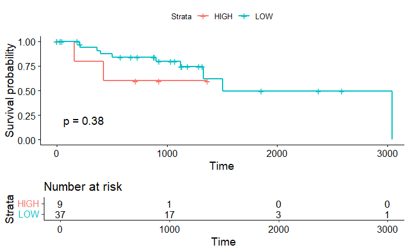

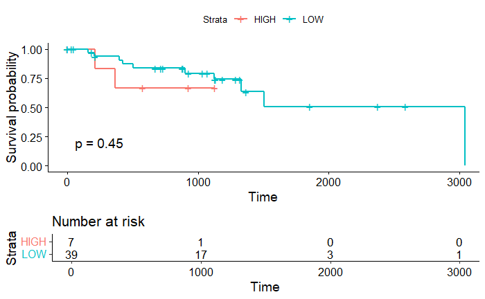

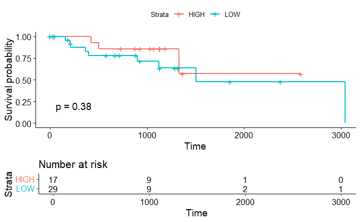

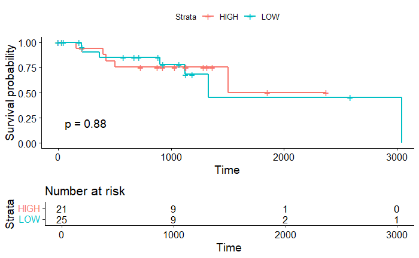

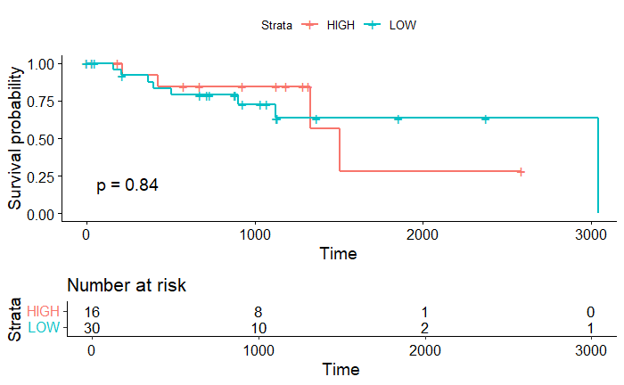

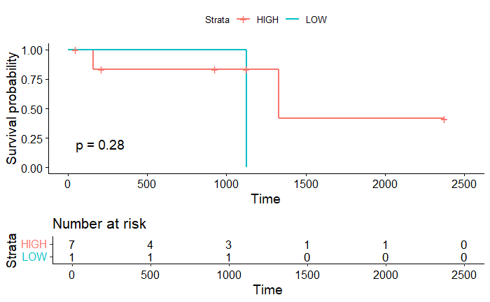

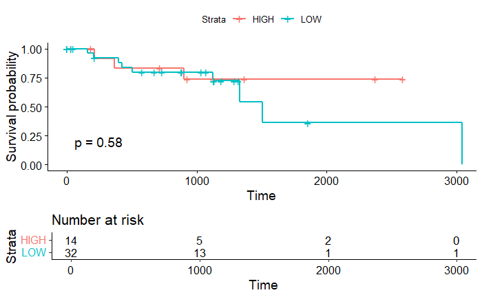

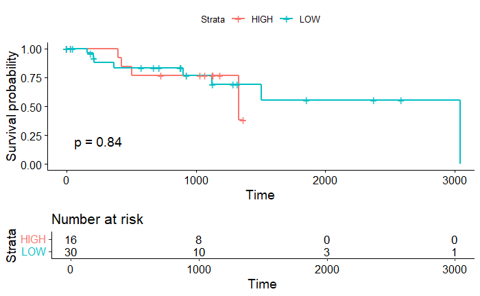

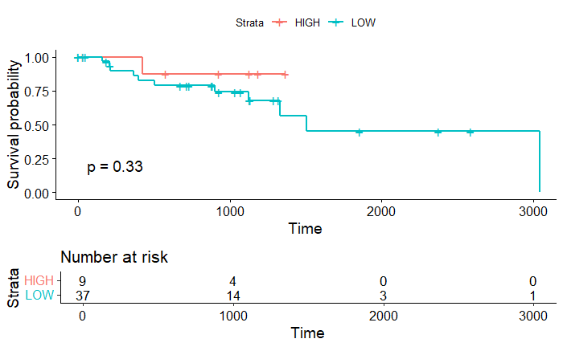

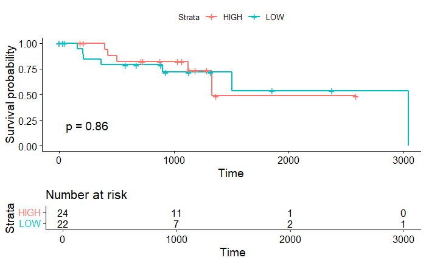

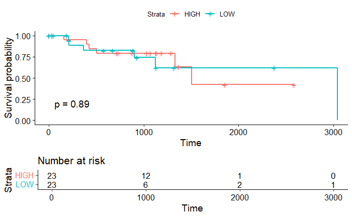

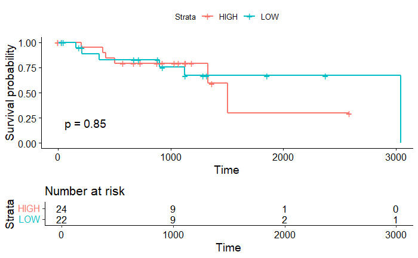

[43 more figures not shown]

```r
significant_projects <- c()
significant_genes <- c()

ctr <- 1
for (project in projects) {
  for (gene in c("MLKL", genes$gene)) {
    cat(project, gene, "\n\n")
    tryCatch (
      {
        gene_df <- construct_gene_df(gene, project)
      },
      error = function(e) {
      }
    )

    if (nrow(gene_df) > 0) {
      fit <- compute_surival_fit(gene_df)
      tryCatch (
        {
          survival <- compute_survival_diff(gene_df)
          cox <- compute_cox(gene_df)
          print(ctr)
          ctr <- ctr + 1
          print(survival)
          cat("\n")
          print(cox)
          print(plot_survival(fit))
          if (pchisq(survival$chisq, length(survival$n)-1, lower.tail = FALSE) < 0.05) {
            significant_projects <- c(significant_projects, project)
            significant_genes <- c(significant_genes, gene)
          }
        },
        error = function(e) {
        }
      )

    }

    cat("\n\n============================\n\n")
  }
}
```

Display the results only for genes where a significant difference in survival has been reported.

```r
significant_genes
```

```r
num_significant_genes <- length(significant_genes)

if (num_significant_genes > 0) {
  for (i in 1 : num_significant_genes) {
    project <- significant_projects[[i]]
    gene <- significant_genes[[i]]

    cat(project, gene, "\n\n")
    gene_df <- construct_gene_df(gene, project)

    survival <- compute_survival_diff(gene_df)
    cox <- compute_cox(gene_df)
    print(survival)
    cat("\n")
    print(cox)
    print(plot_survival(fit))

    cat("\n\n============================\n\n")
  }
}
```

[^1]: De La Salle University, Manila, Philippines, gonzales.markedward@gmail.com
[^2]: De La Salle University, Manila, Philippines, anish.shrestha@dlsu.edu.ph